# Midterm 1 - Fall 2025

Author

SOLUTION GUIDE

## Midterm Logistics

**Exam should be completed by 8:00 pm.** However, I will give you a ‘grace period’ in case of technology or personal issues; **exam deliverable items are due without penalty BEFORE 8:30 pm** under: Assignments > Midterm 1 on Canvas.

I will accept late submissions starting 8:30pm up to 11:59pm of October 15 (yes–the next day) but your maximum exam score would be capped at 85%.

**Failure to submit a properly rendered HTML file, due to code errors in your qmd file, will also result in your maximum exam score being capped to 90%.**

You will have to submit the quarto document (.qmd file) with your solutions and responses, the rendered HTML file (.html file), an R script file (.R file), and data extract(s) (e.g., csv files) I may ask you to create.

This exam is an open ‘book’ exam meaning you are allowed to consult, use, or leverage class materials as needed. **But you need to work on this exam by yourself only–you are not allowed to receive assistance from anyone other than the course instructor.**

## Self Certification

By submitting this midterm file to Canvas, you certify that you completed this midterm independently without unauthorized assistance. Failure to do so constitutes academic dishonesty and may result in a referral to the Office of Academic Integrity for investigation. I further acknowledge that receiving help from anyone other than the instructor for this midterm is considered inappropriate collaboration under American University’s Academic Integrity Code.

## Loading Required Packages

```r
library(tidyverse)
library(readxl)
library(palmerpenguins)
library(nycflights13)
```

## Question 1

For question 1 and its subparts, you will need to load **rural_development_data** into your R env’t by running the following script:

```r
rural_development_data <- read_csv("https://raw.githubusercontent.com/jmtfeliciano/teachingdata/refs/heads/main/RuralDevelopmentInvestments.csv")
head(rural_development_data, 10)
```

```
# A tibble: 10 × 6
   fiscal_year state_name program_area total_investment_dol…¹ number_investments
         <dbl> <chr>      <chr>                         <dbl>              <dbl>
 1        2012 Alabama    Business Pr…               16027910                 24
 2        2012 Alabama    Community F…                2808761                 18
 3        2012 Alabama    Electric Pr…               46990000                  2
 4        2012 Alabama    Multifamily…               25069905                303
 5        2012 Alabama    Single Fami…              486125173               4186
 6        2012 Alabama    Telecommuni…                 405147                  1
 7        2012 Alabama    Water and E…               27815106                 23
 8        2012 Alaska     Business Pr…               13622360                 20
 9        2012 Alaska     Community F…                3475921                 11
10        2012 Alaska     Electric Pr…                1443779                  2
# ℹ abbreviated name: ¹total_investment_dollars
# ℹ 1 more variable: svi_investments <dbl>
```

## Question 1 Background

rural_development_data is an extract from USDA Rural Development’s dashboard found on https://www.rd.usda.gov/rural-data-gateway/rural-investments

**fiscal_year** is the fiscal year, ranges from 2012-2024 (Note: 2024 is only partial data)

**state_name** includes the state name or territory name

**program_area** is the USDA program area that made the investment (Business Programs, Community Facilities, Electric Programs, Multifamily Housing, Single Family Housing, Telecommunications Programs, Water and Environmental)

**total_investment_dollars** is the total USDA investment made by Rural Development (one of USDA’s agencies)

**number_investments** is the total investment counts made by Rural Development (one of USDA’s agencies)

**svi_investments** is the total USDA investment that went towards communities that are considered socially vulnerable

Make sure to understand the data before attempting any additional tasks.

**Again: make sure you loaded the rural_development_data into the R env’t**

## Question 1.a. (5 pts)

Using one or more dplyr verbs with rural_development_data, print the one data row where the fiscal year is 2019, program area is Business Programs and the state name is Alaska using the R chunk below.

```r
# Include required R script below:
rural_development_data |>
  filter(fiscal_year == 2019,
         program_area == "Business Programs",
         state_name == "Alaska")
```

```
# A tibble: 1 × 6
  fiscal_year state_name program_area  total_investment_dol…¹ number_investments
        <dbl> <chr>      <chr>                          <dbl>              <dbl>
1        2019 Alaska     Business Pro…                5513704                 22
# ℹ abbreviated name: ¹total_investment_dollars
# ℹ 1 more variable: svi_investments <dbl>
```

## Question 1.b. (5 pts)

Using one or more dplyr verbs with rural_development_data, calculate (if necessary) then print the sum of investments that went towards communities that are considered socially vulnerable broken down by state:

```r
# Include your R script below:
rural_development_data |>
  group_by(state_name) |>
  summarise(total_svi_investments = sum(svi_investments))
```

```
# A tibble: 52 × 2
   state_name           total_svi_investments
   <chr>                                <dbl>
 1 Alabama                         1482282596
 2 Alaska                           905049938
 3 Arizona                         2032961995
 4 Arkansas                        1190022116
 5 California                      6710958870
 6 Colorado                         902620147
 7 Connecticut                      115544252
 8 Delaware                         396130890
 9 District of Columbia                363285
10 Florida                         2726760867
# ℹ 42 more rows
```

## Question 1.c. (5 pts)

Using one or more dplyr verbs and the rural_development_data data, calculate (if necessary) then print the overall sum of total investment (in $) for the state of Arkansas in Fiscal Year 2019 using the R chunk below.

```r
# Include your R script below:
rural_development_data |>
  filter(state_name == "Arkansas", fiscal_year == 2019) |>
  summarise(sum_2019_ak = sum(total_investment_dollars))
```

```
# A tibble: 1 × 1
  sum_2019_ak
        <dbl>
1   865002489
```

## Question 1.d. (5 pts)

The table you will need to complete (see prompt below):

| State | Total USDA Water and Environmental Investment in FY2019-2020 |
| --- | --- |
| Minnesota | $62,806,543 |
| Indiana | $151,666,587 |
| Maryland | $25,964,680 |
| South Dakota | $85,145,600 |
| Georgia | $38,081,274 |

Using rural_development_data, fill in the empty table above where you need to calculate the Water and Environmental investments in 2019-2020 in five certain states. You will not get credit unless you write an R code within the following R chunk that prints this insight. Note: if the R chunk below partially obscures the output you need to copy from, please rerun the code via the R console for an unobstructed view of the output

```r
# Include your R script below:
rural_development_data |>
  filter(between(fiscal_year, 2019, 2020)) |>
  filter(program_area == "Water and Environmental") |>
  # or filter(fiscal_year >= 2019, fiscal_year <= 2020)
  filter(state_name %in% c("Minnesota", "Indiana", "Maryland", "South Dakota", "Georgia")) |>
  group_by(state_name) |>
  summarise(wep_total = sum(total_investment_dollars))
```

```
# A tibble: 5 × 2
  state_name   wep_total
  <chr>            <dbl>
1 Georgia       38081274
2 Indiana      151666587
3 Maryland      25964680
4 Minnesota     62806543
5 South Dakota  85145600
```

## Question 1.e. (5 pts)

The table you will need to complete (see prompt below):

| Top 5 states/territories that received the highest counts of investments | Investment Counts (#) |
| --- | --- |
| North Carolina | 87718 |
| Michigan | 85854 |
| Missouri | 83355 |
| Tennessee | 83354 |
| Texas | 78299 |

Using rural_development_data, fill in the empty table above where you need to identify the top five states that received the most investment counts. You will not get credit unless you write an R code within the following R chunk that prints this insight below that you can copy from. Note: if the R chunk below partially obscures the output you need to copy from, please rerun the code via the R console for an unobstructed view of the output

```r
# Include required R script below:
rural_development_data |>
  group_by(state_name) |>
  summarise(total_counts = sum(number_investments)) |>
  arrange(-total_counts)
```

```
# A tibble: 52 × 2
   state_name     total_counts
   <chr>                 <dbl>
 1 North Carolina        87718
 2 Michigan              85854
 3 Missouri              83355
 4 Tennessee             83354
 5 Texas                 78299
 6 Indiana               76055
 7 Louisiana             70335
 8 Ohio                  65364
 9 Pennsylvania          63630
10 Florida               62335
# ℹ 42 more rows
```

## Question 1.f. (5 pts)

Using one or more dplyr verbs with the rural_development_data, calculate and print both the mean investment and overall sum of **total_investment_dollars** by **program_area** for the state of Hawaii only using one summarize() verb within the R chunk below. One of the statistic columns shall be named **overall_hawaii_investment** and it will be the sum of **total_investment_dollars** and the other statistic column shall be called **mean_hawaii_investment** and it will be the mean **total_investment_dollars**

```r
# Include required R script below:
rural_development_data |>
  filter(state_name == "Hawaii") |>
  group_by(program_area) |>
  summarize(overall_hawaii_investment = sum(total_investment_dollars),
            mean_hawaii_investment = mean(total_investment_dollars))
```

```
# A tibble: 7 × 3
  program_area                overall_hawaii_investment mean_hawaii_investment
  <chr>                                           <dbl>                  <dbl>
1 Business Programs                           119380189               9183091.
2 Community Facilities                        102642609               7895585.
3 Electric Programs                           160927774              32185555.
4 Multifamily Housing                         137601725              10584748.
5 Single Family Housing                      2391668230             183974479.
6 Telecommunications Programs                   1508774                502925.
7 Water and Environmental                      69646141               7738460.
```

## Question 2.a. (1 pt)

Load **cms_patient_care**, a built-in Tidyverse data set, into the R env’t. As always, print sample data by using head() or glimpse() below. Consult the official documentation via the Help pane if needed.

```r
# Include required R script below:
data("cms_patient_care")

head(cms_patient_care)
```

```
# A tibble: 6 × 5
  ccn    facility_name   measure_abbr      score type
  <chr>  <chr>           <chr>             <dbl> <chr>
1 011500 BAPTIST HOSPICE beliefs_addressed 202   denominator
2 011500 BAPTIST HOSPICE beliefs_addressed 100   observed
3 011500 BAPTIST HOSPICE composite_process 202   denominator
4 011500 BAPTIST HOSPICE composite_process  88.1 observed
5 011500 BAPTIST HOSPICE dyspena_treatment 110   denominator
6 011500 BAPTIST HOSPICE dyspena_treatment  99.1 observed
```

## Question 2.b. (4 pts)

Note: The wide format you need to generate below should look partially like the table below:

| ccn | facility_name | measure_abbr | denominator | observed |
| --- | --- | --- | --- | --- |
| 011500 | BAPTIST HOSPICE | beliefs_addressed | 202 | 100 |
| 011500 | BAPTIST HOSPICE | composite_process | 202 | 88.1 |
| … | … | … | … | … |

Use pivot_wider() below to transform the **cms_patient_care** data into wide format via the R code chunk provided below. Also save the data into your R environment (name it however you want) then print a sample of that data using head() or glimpse() within the R code chunk below:

```r
# Include required R script below:
wider_data <- cms_patient_care |>
  pivot_wider(names_from = type,
              values_from = score)

head(wider_data)
```

```
# A tibble: 6 × 5
  ccn    facility_name   measure_abbr      denominator observed
  <chr>  <chr>           <chr>                   <dbl>    <dbl>
1 011500 BAPTIST HOSPICE beliefs_addressed         202    100
2 011500 BAPTIST HOSPICE composite_process         202     88.1
3 011500 BAPTIST HOSPICE dyspena_treatment         110     99.1
4 011500 BAPTIST HOSPICE dyspnea_screening         202    100
5 011500 BAPTIST HOSPICE opioid_bowel               61    100
6 011500 BAPTIST HOSPICE pain_assessment           107    100
```

## Question 3 (5 pts)

Generate an R script file that meets the following:

(1) File name is: plottingmileage.R

(2) The first line has your full name as a comment.

(3) Contains R code (including all packages-related code) you need to generate a scatter plot.

(4) The scatter plot uses `mpg`, a built-in Tidyverse data with: the city miles per gallon (i.e., city mileage) on the x-axis and the highway miles per gallon (i.e., highway mileage) on the y-axis.

(5) The final image is customized and properly labelled with at least following information: “city mileage (mpg)” on the x-axis and “highway mileage (mpg)” on the y-axis.

Please submit your plottingmileage.R file along with other midterm-related files you need to submit on Canvas.

## Question 4 (5 pts)

Pay close attention to this image before proceeding:

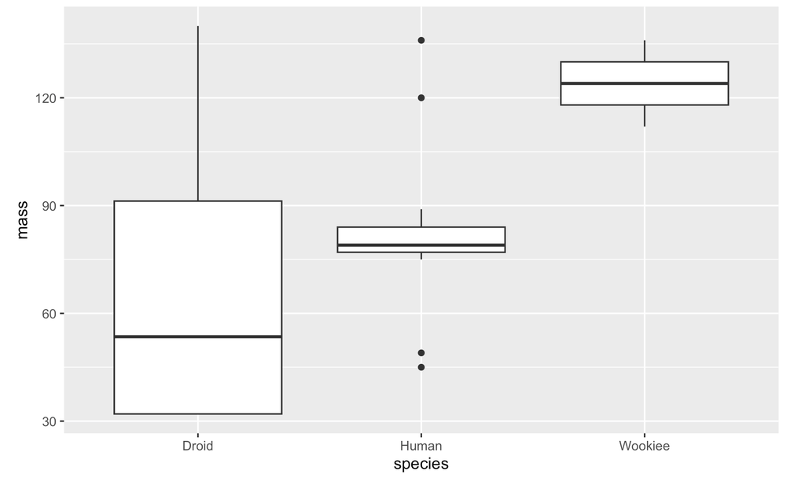

Note 1: If the image above is not showing, please open your internet browser and visit: https://github.com/jmtfeliciano/teachingdata/blob/main/referencedimage/starwars_boxplot.png

Note 2: pay attention to the actual variable names and their contents (possibly filtered) on the x- and y-axis.

To create the image above, I first loaded **starwars**, a built-in tidyverse data, into the R env’t then created another new data subset in the R env’t after manipulating the **starwars** data set using dplyr verb(s) or function(s). Using that new manipulated data set in the R env’t, I created the data visualization above. Using the code chunk below, write a series of R scripts to regenerate the exact image I generated above by using the hints I provided above.

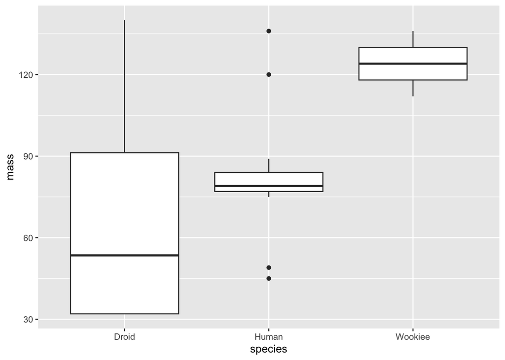

```r
# Include required R script below:
data("starwars")

starwars_v2 <- starwars |>
  filter(species %in% c("Droid", "Human", "Wookiee"))

ggplot(starwars_v2, aes(x = species, y = mass)) +
  geom_boxplot()
```

## Question 5.a. (5 pts)

Within the following R chunk, read the **clean** sheet from **cancer_atlas.xlsx** into your R environment and use head() to print the data you made. Name this data however you want but make sure it follows the best practice for naming variables in R. **Actually spend a min or two investigating and reading the data from left to right! Consider opening the excel too using your computer for investigation.**

**Note:** if you are having a hard time reading the excel file from your local computer, you may use the following (but you will get 0 pts for 5.a.) read_csv() script as a backup:

> read_csv(“https://raw.githubusercontent.com/jmtfeliciano/teachingdata/refs/heads/main/cancer_atlas_csv.csv”)

```r
# Include required R script below:
cancer_data <- read_xlsx("data/cancer_atlas.xlsx", sheet = "clean")
head(cancer_data)
```

```
# A tibble: 6 × 13
  state       iso3_code alcohol_cancer_deaths smoking_prevalence_male
  <chr>       <chr>                     <dbl>                   <dbl>
1 Puerto Rico PRI                        NA                      NA
2 Tokelau     TKL                        NA                      NA
3 Afghanistan AFG                         0.5                    21.4
4 Algeria     DZA                         1.1                    17.5
5 Azerbaijan  AZE                         3.2                    36.7
6 Albania     ALB                         4.9                    40.9
# ℹ 9 more variables: smoking_prevalence_female <dbl>,
#   obesity_prevalence_male <dbl>, obesity_prevalence_female <dbl>,
#   lung_cancer_incidence_male <dbl>, lung_cancer_incidence_female <dbl>,
#   most_common_female_cancer_case <chr>,
#   most_common_female_cancer_death <chr>, most_common_male_cancer_case <chr>,
#   most_common_male_cancer_death <chr>
```

## Question 5.a. Background Information

The cancer_atlas.xlsx data is a data extract from the World Health Organization (WHO)’s Global Cancer Observatory data. The detailed variable documentation for this partial data is as follows:

**state**: state, country, or territory with data, whether partial or full.

**iso3_code**: three-letter country codes defined in ISO 3166-1

**alcohol_cancer_death**: Cancer deaths attributable to alcohol. Proportion (%) of cancer deaths caused by alcohol drinking in men ages 15 years or older, 2016.

s**moking_prevalence_male**: Smoking prevalence male. Prevalence (%) of daily smoking for men.

**smoking_prevalence_female**: Smoking prevalence female. Prevalence (%) of daily smoking for women.

**obesity_prevalence_male**: Obesity prevalence male for 2016.

**obesity_prevalence_female:** Obesity prevalence female for 2016.

**lung_cancer_incidence_male:** Lung cancer incidence rates, male Age-standardized rate (world) per 100,000, all ages, 2018.

**lung_cancer_incidence_female:** Lung cancer incidence rates, female Age-standardized rate (world) per 100,000, all ages, 2018.

**most_common_female_cancer_case**: Most common cancer type in the country for females (in 2018) (e.g., Breast, Kaposi sarcoma)

**most_common_female_cancer_death**: Most common cancer type deaths in the country for females (in 2018) (e.g., Breast, Kaposi sarcoma)

**most_common_male_cancer_case**: Most common cancer type in the country for males (in 2018) (e.g., Breast, Kaposi sarcoma)

**most_common_male_cancer_death**: Most common cancer type deaths in the country for males (in 2018) (e.g., Breast, Kaposi sarcoma)

## Question 5.b. (5 pts)

Using data you generated in Question 5.a. and the R chunk provided below, create a data subset in your R env’t that only includes the following three variables: state, most_common_male_cancer_case, most_common_male_cancer_death

**Note:** You are not allowed to base R notation for this (e.g., data$test <- as.numeric(data$test). If your data looks funny, revisit your solution for 5.a.

Name this data/object in your R env’t however you see fit. Afterwards, create/write a csv file using the R data subset you created and name it **MaleCancerCasesDeaths.csv** which you will need to submit on Canvas as one of the midterm items

```r
# Include required R script below:
cancer_data_5b <- cancer_data |>
  select(state, most_common_male_cancer_case, most_common_male_cancer_death)

cancer_data_5b |>
  write_csv("data/MaleCancerCasesDeaths.csv")
```

## Question 5.c. (5 pts)

Suppose you are a WHO cancer epidemiologist looking into the relationship between the prevalence of daily smoking for women and lung cancer incidence for women. Create a scatter plot between these two variables (3 pts) with a linear trend line (2 pts) using the R chunk below:

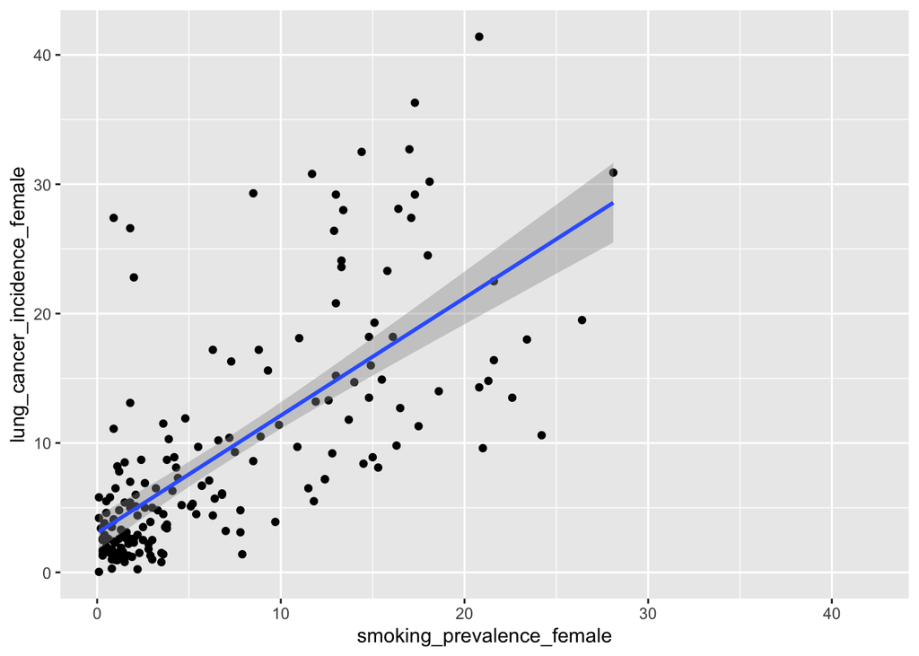

```r
# Include required R script below:
ggplot(cancer_data, aes(x = smoking_prevalence_female,
                        y = lung_cancer_incidence_female)) +
  geom_point() +
  geom_smooth(method = "lm")
```

## Question 5.d. (5 pts)

**Question:**

> Suppose you are a WHO public health staff who wants to conduct a pilot cancer-targeting vaccine program in countries where the most common cancer death in males is caused by: **Kaposi sarcoma**

> **Which four countries (where Kaposi sarcoma is the most common cancer death) would you recommend for the pilot cancer-targeting vaccine program?** Using any techniques (or combination of techniques) you were taught in class, use the R chunk below to generate the necessary output to answer this question.

**Your response:**

> There are only four countries where Kaposi sarcoma is the most common cause of male cancer death. Therefore, I would target those four countries: Botswana, Malawi, Mozambique, and Uganda.

This is an R chunk you need to use to answer the question(s) above:

```r
# Include required R script below:
cancer_data |>
  filter(most_common_male_cancer_death == "Kaposi sarcoma")
```

```
# A tibble: 4 × 13
  state      iso3_code alcohol_cancer_deaths smoking_prevalence_male
  <chr>      <chr>                     <dbl>                   <dbl>
1 Botswana   BWA                        10.6                    25.4
2 Malawi     MWI                         3.8                    16.7
3 Mozambique MOZ                         1.5                    21.7
4 Uganda     UGA                         8.4                     9.8
# ℹ 9 more variables: smoking_prevalence_female <dbl>,
#   obesity_prevalence_male <dbl>, obesity_prevalence_female <dbl>,
#   lung_cancer_incidence_male <dbl>, lung_cancer_incidence_female <dbl>,
#   most_common_female_cancer_case <chr>,
#   most_common_female_cancer_death <chr>, most_common_male_cancer_case <chr>,
#   most_common_male_cancer_death <chr>
```

## Question 5.e. (5 pts)

The table you will need to complete (see prompt below):

| Countries (Top 5 in Female Obesity Prevalence) | Prevalence (% of Population) |
| --- | --- |
| Nauru | 63.3 |
| Cook Islands | 59.2 |
| Palau | 58.8 |
| Marshall Islands | 57.3 |
| Tuvalu | 56.2 |

Suppose you are a WHO staff who oversees a Women’s Health grant program that issues public health education grants to countries with the **highest female obesity prevalence**. Using any techniques (or combination of techniques) you were taught in class, report the top 5 countries or nation states with the highest female obesity prevalence. Include scripts within the R code chunk below that you used to generate the insight required. Afterwards, complete the table above by filling in the relevant insight you gained from your scripts’ output(s). **Hint to make output easier to copy from:** You may want to use select() to limit the output to variables you only care about or move the columns you need to copy from to the left most columns by using relocate()

```r
# Include required R script below:
cancer_data |>
  select(state, obesity_prevalence_female) |>
  arrange(- obesity_prevalence_female) |>
  head(5)
```

```
# A tibble: 5 × 2
  state            obesity_prevalence_female
  <chr>                                <dbl>
1 Nauru                                 63.3
2 Cook Islands                          59.2
3 Palau                                 58.8
4 Marshall Islands                      57.3
5 Tuvalu                                56.2
```

## Question 6.a. (5 pts)

Within the following R chunk, read **glp1_trial.csv** from you local computer into your R environment and use head() or glimpse() to print the data you made. Name this data however you want but make sure it follows the best practice for naming variables in R.

**Note:** if you are having a hard time reading the file from your local computer, you may use the following (but you will get 0 pts for 10.a.) as a backup only:

> read_csv(“https://raw.githubusercontent.com/jmtfeliciano/teachingdata/refs/heads/main/glp1_trial.csv”)

```r
# Include required R script below:
glp_data <- read_csv("data/glp1_trial.csv")
head(glp_data)
```

```
# A tibble: 6 × 5
  patient_id drug        sex    percent_weight_loss initial_bmi
  <chr>      <chr>       <chr>                <dbl>       <dbl>
1 PW8024     Tirzepatide Male                  20.4        30.6
2 AL7213     Tirzepatide Male                  21.2        31.8
3 LD9010     Semaglutide Female                10.7        24.2
4 WC4672     Drug AZ1Q29 Female                31.6        30.8
5 YT9996     Drug AZ1Q29 Male                  33.0        36.0
6 XP8962     Drug AZ1Q29 Male                  34          26.9
```

## Question 6.a. Background Information

This simulated hypothetical clinical trials data compares the effectiveness of a new proposed GLP-1 drug called Drug AZ1Q29 against two FDA-approved GLP-1 medication (tirzepatide, semaglutide) for diabetes and weight loss. Tirzepatide is the active ingredient for both Mounjaro and Zepbound, while semaglutide is the active ingredient for Ozempic.

**Each row corresponds to a unique clinical trial participant.**

- **patient_id** is the unique patient identifier for the clinical trial participant
- **drug** is the active ingredient (Drug AZ1Q29, Semaglutide, Tirzepatide)
- **sex** is the assigned sex at birth
- **percent_weight_loss** is the % of total weight loss after a year of taking the drug.

## Question 6.b. (5 pts)

Using data you generated for Question 6.a., generate a box plot the drug is on the x-axis and percent weight loss is on the y-axis using ggplot() below:

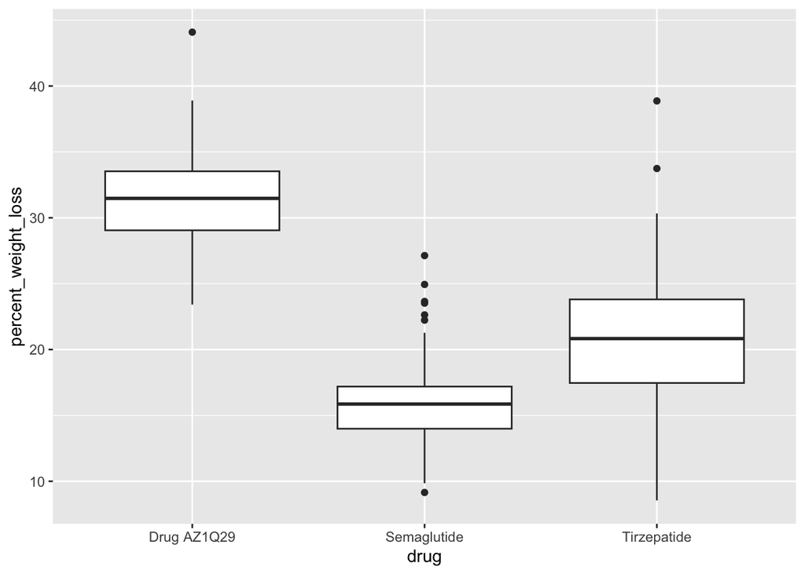

```r
# Include required R script below:
ggplot(glp_data, aes(x= drug, y = percent_weight_loss)) +
  geom_boxplot()
```

## Question 6.c. (5 pts)

The table you will need to complete (see prompt below):

| Drug | Number of Enrolled Clinical Trial Participant | Median % Weight Loss |
| --- | --- | --- |
| Drug AZ1Q29 | 89 | 31.47 |
| Semaglutide | 92 | 15.86 |
| Tirzepatide | 95 | 20.83 |

Using the data you loaded in Question 6.a., compute the number of enrolled clinical trial participant and the *exact* median % weigh loss for each of the three drugs. Use the R chunk below to compute the requested information then fill in the table using the printed output you generated.

```r
# Include required R script below:
glp_data |>
  group_by(drug) |>
  summarise(n = n(), median_loss = median(percent_weight_loss))
```

```
# A tibble: 3 × 3
  drug            n median_loss
  <chr>       <int>       <dbl>
1 Drug AZ1Q29    89        31.5
2 Semaglutide    92        15.9
3 Tirzepatide    95        20.8
```

```r
# or summarise(n = n_distinct(patient_id), median_loss = median(percent_weight_loss))
```

## Question 7 Data

Load the systolic_data_wide data into R by running the script below and pay close attention to the structure and information that is included (e.g., see printed variables/output). The data collected are for 50 patients with history of hypertensive crisis with information on age and sex. month0 represents the initial systolic blood pressure before they started medication, whereas month3 is the measured systolic blood pressure after taking medications everyday for three months.

```r
# Make sure to run this to load data
systolic_data_wide <- read_csv("https://raw.githubusercontent.com/jmtfeliciano/teachingdata/refs/heads/main/systolic_data_wide.csv")
head(systolic_data_wide)
```

```
# A tibble: 6 × 7
  patient_id   age sex    month0 month1 month2 month3
  <chr>      <dbl> <chr>   <dbl>  <dbl>  <dbl>  <dbl>
1 Subject1      47 Male      162    128    132    113
2 Subject2      49 Male      160    122    142    109
3 Subject3      39 Male      140    152    132    110
4 Subject4      34 Female    156    119    131    118
5 Subject5      48 Male      163    128    121    110
6 Subject6      17 Male      158    156    125    110
```

## Question 7.a. (5 pts)

Note: The long format you need to generate below should look partially like the table below:

| patient_id | age | sex | month | systolic_pressure |
| --- | --- | --- | --- | --- |
| Subject1 | 47 | Male | month0 | 162 |
| … | … | … | … | … |
| Subject1 | 47 | Male | month3 | 113 |
| Subject2 | 49 | Male | month0 | 160 |
| … | … | … | … | … |

Use pivot_longer() to transform the systolic_data_wide data into long format via the R code chunk provided below. Also save the data into your R environment (name it systolic_data_long) then print a sample of that data using head() or glimpse() within the same R code chunk.

```r
# Include required R script below:
systolic_data_long <- systolic_data_wide |>
  pivot_longer(cols = month0:month3,
              names_to = "month",
              values_to = "systolic_pressure")

head(systolic_data_long)
```

```
# A tibble: 6 × 5
  patient_id   age sex   month  systolic_pressure
  <chr>      <dbl> <chr> <chr>              <dbl>
1 Subject1      47 Male  month0               162
2 Subject1      47 Male  month1               128
3 Subject1      47 Male  month2               132
4 Subject1      47 Male  month3               113
5 Subject2      49 Male  month0               160
6 Subject2      49 Male  month1               122
```

## Question 7.b. (5 pts)

Using systolic_data_wide_v2 (you will create this below—read prompt after table) and the R chunk provided, please fill in the table below. Note: generally, you’d like systolic blood pressure to be lower than higher in most cases.

| Question | Your Response |
| --- | --- |
| What is the patient_id with the greatest improvement in systolic blood pressure (Note: the higher the drop/reduction, the greater the improvement) | Subject44 |
| What is the patient_id with the least improvement in systolic blood pressure (Note: the higher the drop, the greater the improvement) | Subject37 |
| What is the median net change in systolic blood pressure? | 43 |
| What is the mean net change in systolic blood pressure? | 43.94 |

Using systolic_data_wide and the R chunk provided after the table, create systolic_data_wide_v2 after creating a variable/column named net_change by subtracting month 3 measurements from month 0 measurements (you are not allowed to use Base R for this math and you will need to use one of the dplyr verbs to assist you on this). This is an R chunk you need to use to answer the question(s) above. You will not get credit unless you properly used R to answer this question:

```r
# Place your code below
systolic_data_wide_v2 <- systolic_data_wide |>
  mutate(net_change = month0 - month3)

# question 1
systolic_data_wide_v2 |>
  select(patient_id, net_change) |>
  arrange(-net_change) |>
  head(1)
```

```
# A tibble: 1 × 2
  patient_id net_change
  <chr>           <dbl>
1 Subject44          73
```

```r
# question 2
systolic_data_wide_v2 |>
  select(patient_id, net_change) |>
  arrange(net_change) |>
  head(1)
```

```
# A tibble: 1 × 2
  patient_id net_change
  <chr>           <dbl>
1 Subject37          17
```

```r
# question 3
systolic_data_wide_v2 |>
  summarise(median_change = median(net_change))
```

```
# A tibble: 1 × 1
  median_change
          <dbl>
1            43
```

```r
# question 4
systolic_data_wide_v2 |>
  summarise(mean_change = mean(net_change))
```

```
# A tibble: 1 × 1
  mean_change
        <dbl>
1        43.9
```

## Question 8.a. (1 pts)

For this problem, you need to load two build-in datasets (flights, planes) from the nycflights13 package into your R environment. Since this is your first time working on the planes table, you may also want to investigate planes via the help pane.

Make sure to print sample data of both data sets (e.g., head) so you can investigate their structure.

```r
# Include required R script below:
data("flights")
data("planes")

head(flights)
```

```
# A tibble: 6 × 19
   year month   day dep_time sched_dep_time dep_delay arr_time sched_arr_time
  <int> <int> <int>    <int>          <int>     <dbl>    <int>          <int>
1  2013     1     1      517            515         2      830            819
2  2013     1     1      533            529         4      850            830
3  2013     1     1      542            540         2      923            850
4  2013     1     1      544            545        -1     1004           1022
5  2013     1     1      554            600        -6      812            837
6  2013     1     1      554            558        -4      740            728
# ℹ 11 more variables: arr_delay <dbl>, carrier <chr>, flight <int>,
#   tailnum <chr>, origin <chr>, dest <chr>, air_time <dbl>, distance <dbl>,
#   hour <dbl>, minute <dbl>, time_hour <dttm>
```

```r
head(planes)
```

```
# A tibble: 6 × 9
  tailnum  year type               manufacturer model engines seats speed engine
  <chr>   <int> <chr>              <chr>        <chr>   <int> <int> <int> <chr>
1 N10156   2004 Fixed wing multi … EMBRAER      EMB-…       2    55    NA Turbo…
2 N102UW   1998 Fixed wing multi … AIRBUS INDU… A320…       2   182    NA Turbo…
3 N103US   1999 Fixed wing multi … AIRBUS INDU… A320…       2   182    NA Turbo…
4 N104UW   1999 Fixed wing multi … AIRBUS INDU… A320…       2   182    NA Turbo…
5 N10575   2002 Fixed wing multi … EMBRAER      EMB-…       2    55    NA Turbo…
6 N105UW   1999 Fixed wing multi … AIRBUS INDU… A320…       2   182    NA Turbo…
```

## Question 8.b. (4 pts)

Suppose you are interesting in studying the most popular plane models that flew in and out of NYC airports. However, the **flights** table do not contain model information about the planes. But another table called **planes** does! More specifically, planes contain a model variable/column that you are interested in. Using the R chunk below, perform the appropriate join to supplement **flights** with data from **planes** to ensure your new data frame contains the model variable/column—make sure to use tailnum as the join key. You may think of tailnum as the aircraft registration number.

For this problem, you may want to use the help pane to read more about planes and its variables.

Save the resulting table or data frame as flights_v2 in your R env’t.

```r
# Include required R script below:
flights_v2 <- flights |>
  left_join(planes, join_by(tailnum ))

head(flights_v2)
```

```
# A tibble: 6 × 27
  year.x month   day dep_time sched_dep_time dep_delay arr_time sched_arr_time
   <int> <int> <int>    <int>          <int>     <dbl>    <int>          <int>
1   2013     1     1      517            515         2      830            819
2   2013     1     1      533            529         4      850            830
3   2013     1     1      542            540         2      923            850
4   2013     1     1      544            545        -1     1004           1022
5   2013     1     1      554            600        -6      812            837
6   2013     1     1      554            558        -4      740            728
# ℹ 19 more variables: arr_delay <dbl>, carrier <chr>, flight <int>,
#   tailnum <chr>, origin <chr>, dest <chr>, air_time <dbl>, distance <dbl>,
#   hour <dbl>, minute <dbl>, time_hour <dttm>, year.y <int>, type <chr>,
#   manufacturer <chr>, model <chr>, engines <int>, seats <int>, speed <int>,
#   engine <chr>
```

## Question 8.c. (5 pts)

Use the R chunk below to help you answer the following question: what are the top five plane models within the augmented flights data set and how many scheduled flights did each have within the flights table?

```r
# Include required R script below:
flights_v2 |>
  group_by(model) |>
  summarise(flight_counts = n()) |>
  arrange(-flight_counts)
```

```
# A tibble: 128 × 2
   model           flight_counts
   <chr>                   <int>
 1 <NA>                    52606
 2 A320-232                45831
 3 EMB-145LR               28027
 4 ERJ 190-100 IGW         23716
 5 EMB-145XR               14051
 6 737-824                 13809
 7 CL-600-2D24             11807
 8 737-7H4                 10389
 9 MD-88                   10191
10 A319-114                 9713
# ℹ 118 more rows
```